# Documentation of analysis and insights into final data

From more than 2000 tweets of the [*dog_rates* twitter](https://twitter.com/dog_rates/) account starting from November 2015 up to July 2017 favorite count averaged over 8,000 and re-tweet count averaged almost 3,000. The maximum favorite count was 164,595 and the maximum re-tweet count was 84,550. Those numbers are really high but haven’t been so from the beginning of the twitter account. In fact as you can see from the plot below where favorite count is represented by the size of the circle the popularity of *dog_rates* twitter increased over time. One the y-axis you can see the ratings which are given to dogs on the out of 10-scale.

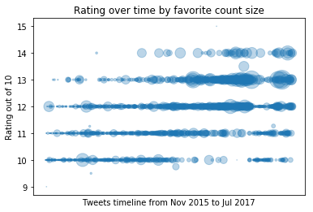

Recently dogs started to receive better ratings with many ratings well over 10 leading to increased popularity of the tweets. May be this interesting rating system is one of things the which keeps people excited about the *dog_rates* twitter.

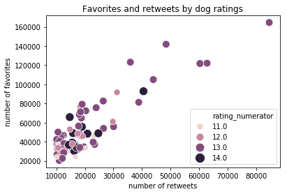

What about dogs whose pictures have been used in the tweets?

From the dataset we could tell that the most common dog name in the dataset is **Charlie** (12 counts), followed by **Cooper**, **Lucy** and **Oliver** (11 counts each). The third place is shared by **Tucker**, **Lola** and **Penny** (10 counts each).

From the predictions made by an image recognition algorithm we can tell that **golden retriever** and **labrador retriever** are the most common types of dogs seen in the tweets.

[figure not shown]

(labrador retriever)

[figure not shown]

(golden retriever)

Some tweets also identify the stage of the dog shown which could be doggo, pupper, puppo or floofer.

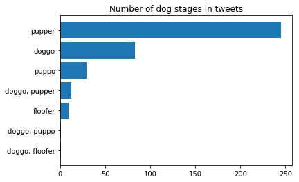

**Pupper** is the most common dog stage represented in the tweets followed by **doggo** and then **puppo**. Sometimes you even can observe them all at once:

[figure not shown]

(https://twitter.com/dog_rates/status/739643777732771844)

Overall, we can definitely conclude:

> [“They are good dogs, Brent”.](https://knowyourmeme.com/memes/theyre-good-dogs-brent)